# COVID-19 Market Prediction Analysis

By [Xia Fu](https://xialalala.github.io/index.html) -- May/02/2020

# Introduction

In the dawn of the new decade, the world has fallen into an unprecedented health crisis. We have never experienced a pandemic in our lives, affecting countless individuals, families and communities. To date, nearly 2.8 million people have been affected by the coronavirus (COVID-19). It is an incredible force that has swept across all continents with a thunderbolt. The global workforce of 2.7 billion people is faced with the closure of all or part of the workplace. Governments are eager to provide stimulus plans to mitigate the impact of the epidemic on the economy. The financial market downturns happened recently because traders react to number of factors such as COVID-19 pandemic and falling oil prices. After knowing the COVID-19 data source of JHU, I planed to do some analysis to visualize the spread of the pandemic. Then, building models to uncover the important factors that caused the market to fall during this pandemic.

# Web Scraping

The COVID-19 data is the underlying data used to produce JHU’s famous JHU CSSE dashboard. To access the data, we need to access this [link to the repository](https://raw.githubusercontent.com/CSSEGISandData/COVID-19/master/csse_covid_19_data/csse_covid_19_daily_reports/) I scraped the data from 03/01/2020 to 4/30/2020 because there are missing coordicates for many countries before 03/01/2020. For some countries or area of countries, the missing latitude or longitude will lead to data missing in the final map. Thus, I assigned the coordicates to make sure they will show in the map.

```r
datahome.url <- "https://raw.githubusercontent.com/CSSEGISandData/COVID-19/master/csse_covid_19_data/csse_covid_19_daily_reports/"

dts <- c("03-01-2020","03-02-2020","03-03-2020",
         "03-04-2020","03-05-2020","03-06-2020","03-07-2020","03-08-2020","03-09-2020",
         "03-10-2020","03-11-2020","03-12-2020","03-13-2020","03-14-2020","03-15-2020",
         "03-16-2020","03-17-2020","03-18-2020","03-19-2020","03-20-2020","03-21-2020",
         "03-22-2020","03-23-2020","03-24-2020","03-25-2020","03-26-2020","03-27-2020",
         "03-28-2020","03-29-2020","03-30-2020","03-31-2020","04-01-2020","04-02-2020",
         "04-03-2020","04-04-2020","04-05-2020","04-06-2020","04-07-2020","04-08-2020",
         "04-09-2020","04-10-2020","04-11-2020","04-12-2020","04-13-2020","04-14-2020",
         "04-15-2020","04-16-2020","04-17-2020","04-18-2020","04-19-2020","04-20-2020",
         "04-21-2020","04-22-2020","04-23-2020","04-24-2020","04-25-2020","04-26-2020",
         "04-27-2020","04-28-2020","04-29-2020","04-30-2020")

col.7 <- c("province.State", "Country.Region", "Last.Update", "Confirmed", "Deaths", "Recovered", "Date")
col.9 <- c("province.State", "Country.Region", "Last.Update", "Confirmed", "Deaths",
           "Recovered", "Latitude", "Longitude", "Date")
col.13 <- c("FIPS", "Admin2", "province.State", "Country.Region", "Last.Update",
            "Latitude", "Longitude", "Confirmed", "Deaths", "Recovered","Active", "Combined.Key", "Date")

covid.df <- list(NA)
k <-1
for (i in 1:length(dts)){
  tmp <- tryCatch({
    covid.df[[k]]<- read.csv(paste0(datahome.url, dts[i], ".csv", sep=""))
    covid.df[[k]]$date <- as.Date(dts[i], format="%m-%d-%Y")
    if (ncol(covid.df[[k]])==7){
      names(covid.df[[k]])<-col.7
    }else if (ncol(covid.df[[k]])==9){
      names(covid.df[[k]])<-col.9
    }else if (ncol(covid.df[[k]])==13){
      names(covid.df[[k]])<- col.13
    }else {}
    k<-k+1
   },
   error = function(e){
     message("* Data does not exist for ", dts[i])
     print(e)
   }
  )
}
tmp <- lapply(covid.df, dim)

# put data into a single dataframe
df.full <- bind_rows(covid.df, .id = "column_label")

# put three different location variables into a single column
df.full$location <- paste(df.full$Admin2, df.full$Province.State,
                          df.full$Country.Region, sep=', ')
```

```r
df.panel <- pdata.frame(df.full, index=c("location", "Date"))

df.panel$Latitude[df.panel$Country.Region == "US"] <- 30.55435
df.panel$Longitude[df.panel$Country.Region == "US"] <- -91.03677
df.panel$Latitude[df.panel$Country.Region == "Canada"] <- 58.027164
df.panel$Longitude[df.panel$Country.Region == "Canada"] <- -105.38086
df.panel$Latitude[df.panel$Country.Region == "MS Zaandam"] <- 52.432999
df.panel$Longitude[df.panel$Country.Region == "MS Zaandam"] <- -4.833
df.panel$Latitude[df.panel$Country.Region == "United Kingdom"] <- 54.237933
df.panel$Longitude[df.panel$Country.Region == "United Kingdom"] <- -2.36967
df.panel$Latitude[df.panel$Country.Region == "Netherlands"] <- 52.132633
df.panel$Longitude[df.panel$Country.Region == "Netherlands"] <- -5.291266
df.panel$Latitude[df.panel$Country.Region == "France"] <- 47.824905
df.panel$Longitude[df.panel$Country.Region == "France"] <- 2.618787

df.panel
```

| column_label | province.State | Country.Region | Last.Update | Confirmed | Deaths | Recovered | Latitude | Longitude | Date | FIPS | Admin2 | Active | Combined.Key | location |
| --- | --- | --- | --- | --- | --- | --- | --- | --- | --- | --- | --- | --- | --- | --- |
| 22 |  | Afghanistan | 3/22/20 23:45 | 40 | 1 | 1 | 33.93911 | 67.709953 | 2020-03-22 | NA |  | 38 | Afghanistan | , , Afghanistan |
| 23 |  | Afghanistan | 2020-03-23 23:19:21 | 40 | 1 | 1 | 33.93911 | 67.709953 | 2020-03-23 | NA |  | 38 | Afghanistan | , , Afghanistan |
| 24 |  | Afghanistan | 2020-03-24 23:37:15 | 74 | 1 | 1 | 33.93911 | 67.709953 | 2020-03-24 | NA |  | 72 | Afghanistan | , , Afghanistan |
| 25 |  | Afghanistan | 2020-03-25 23:33:04 | 84 | 2 | 2 | 33.93911 | 67.709953 | 2020-03-25 | NA |  | 80 | Afghanistan | , , Afghanistan |
| 26 |  | Afghanistan | 2020-03-26 23:48:18 | 94 | 4 | 2 | 33.93911 | 67.709953 | 2020-03-26 | NA |  | 88 | Afghanistan | , , Afghanistan |
| 27 |  | Afghanistan | 2020-03-27 23:23:03 | 110 | 4 | 2 | 33.93911 | 67.709953 | 2020-03-27 | NA |  | 104 | Afghanistan | , , Afghanistan |
| 28 |  | Afghanistan | 3/28/20 23:05 | 110 | 4 | 2 | 33.93911 | 67.709953 | 2020-03-28 | NA |  | 104 | Afghanistan | , , Afghanistan |
| 29 |  | Afghanistan | 3/29/20 23:08 | 120 | 4 | 2 | 33.93911 | 67.709953 | 2020-03-29 | NA |  | 114 | Afghanistan | , , Afghanistan |
| 30 |  | Afghanistan | 3/30/20 22:52 | 170 | 4 | 2 | 33.93911 | 67.709953 | 2020-03-30 | NA |  | 164 | Afghanistan | , , Afghanistan |
| 31 |  | Afghanistan | 2020-03-31 23:43:43 | 174 | 4 | 5 | 33.93911 | 67.709953 | 2020-03-31 | NA |  | 165 | Afghanistan | , , Afghanistan |

[output cut: 990 more lines]

## Topic 1⃣️: Visualizing confirmed cases in each country on 04/30/2020

### I.i Data Processing

I selected the data on 04/30/2020, removed the records where confirmed case is 0. I hope those confirmed case is 0 not showing in our map. We know that there are some cases confirmed on Cruises, such as Diamond Priness and Grand Princess, because this is not confirmed in country so that I removed those records.

Then, grouping by `Country.Region` and `mutate()` other columns, and keep only the first record for each Country.

```r
my.cases <- df.panel[which(df.panel$Date == '2020-04-30'),]
my.cases <- my.cases[which(my.cases$Confirmed != 0),]

my.cases <- my.cases[which(my.cases$province.State!="Diamond Princess"),]
my.cases <- my.cases[which(my.cases$province.State!="Grand Princess"),]

my.cases<- my.cases[which(my.cases$Latitude != ""),]

my.cases<- my.cases %>%
  group_by(Country.Region)%>%
  mutate(Confirmed.country=sum(Confirmed)) %>%
  mutate(Deaths.country = sum(Deaths)) %>%
  mutate (Recovered.country = sum(Recovered)) %>%
  mutate (n= ifelse(row_number()==1, 1, 0)) %>%
  mutate (Latitude = mean(Latitude)) %>%
  mutate (Longitude = mean(Longitude)) %>%
  ungroup()

df.All.countries <- my.cases[which(my.cases$n==1),]

df.All.countries$Confirmed <- df.All.countries$Confirmed.country
df.All.countries$Deaths <- df.All.countries$Deaths.country
df.All.countries$Recovered<-df.All.countries$Recovered.country
df.All.countries$Confirmed.country<-NULL
df.All.countries$Recovered.country<-NULL
df.All.countries$Deaths.country<-NULL
df.All.countries$n<-NULL
df.All.countries$Last.Update<-NULL

head(df.All.countries, 6)
```

| column_label | province.State | Country.Region | Confirmed | Deaths | Recovered | Latitude | Longitude | Date | FIPS | Admin2 | Active | Combined.Key | location |
| --- | --- | --- | --- | --- | --- | --- | --- | --- | --- | --- | --- | --- | --- |
| 61 |  | Afghanistan | 2171 | 64 | 260 | 33.93911 | 67.70995 | 2020-04-30 | NA |  | 1847 | Afghanistan | , , Afghanistan |
| 61 |  | Albania | 773 | 31 | 470 | 41.15330 | 20.16830 | 2020-04-30 | NA |  | 272 | Albania | , , Albania |
| 61 |  | Algeria | 4006 | 450 | 1779 | 28.03390 | 1.65960 | 2020-04-30 | NA |  | 1777 | Algeria | , , Algeria |
| 61 |  | Andorra | 745 | 42 | 468 | 42.50630 | 1.52180 | 2020-04-30 | NA |  | 235 | Andorra | , , Andorra |
| 61 |  | Angola | 27 | 2 | 7 | -11.20270 | 17.87390 | 2020-04-30 | NA |  | 18 | Angola | , , Angola |
| 61 |  | Antigua and Barbuda | 24 | 3 | 11 | 17.06080 | -61.79640 | 2020-04-30 | NA |  | 10 | Antigua and Barbuda | , , Antigua and Barbuda |

### I.ii Visualization

After cleaning and grouping, our data is ready for visualization. I added **circle markers** to indicate each country/region, and intuitively show the number of cases. Besides, in the tooltip, it gives more information including number of **deaths** and **recovered**.

```r
big <- 12
small <- 1
df.All.countries$radius <- small+(log(1+df.All.countries$Confirmed)/log(max(df.All.countries$Confirmed)))*10

# Create a color palette with handmade bins.
mybins <- c( 0, 1000, 10000,50000, 100000, 500000, 1000000, max(df.All.countries$Confirmed) )
mypalette <- colorBin( palette="YlOrBr", domain=df.All.countries$Confirmed, na.color="transparent", bins=mybins)

# Prepare the text for the tooltip:
mytext <- paste(
  "Location: ", df.All.countries$location, "<br/>", #line breaks
  "Confirmed: ", df.All.countries$Confirmed, "<br/>",
  "Deaths: ", df.All.countries$Deaths,"<br/>",
  "Recovered: ", df.All.countries$Recovered, sep="") %>%
  lapply(htmltools::HTML)

# Final Map
m.day <- leaflet(df.All.countries) %>%
  addTiles()  %>%
  setView( lat=mean(df.All.countries$Latitude),
           lng=mean(df.All.countries$Longitude), zoom=2) %>%
  addProviderTiles("Esri.WorldImagery") %>% #background map
  addCircleMarkers(~Longitude, ~Latitude,
                   fillColor = ~mypalette(Confirmed), fillOpacity = 0.7, color="white", radius=~radius,
                   stroke=FALSE,label = mytext,
                   labelOptions = labelOptions( style = list("font-weight" = "normal",
                                                  padding = "3px 8px"), textsize = "13px", direction = "auto")
  ) %>%
leaflet::addLegend(pal=mypalette, values=~Confirmed, opacity=0.9, title = "Confirmed Cases", position = "bottomright" )
m.day
```

[interactive chart not shown]

Now we have the above world map that shows the confirmed case on 04/30/2020. We can zoom in and out the map and click on the circle marker to get the detailed information about that country/region.

## Topic 2⃣: Time-series visualization of the confirmed cases

### II.i Data Processing

First, I selected the data from 2020-04-22 to 2020-04-30 to do the time-series analysis. Similarly, deleted the records that confirmed on the cruises and all records were grouped by `Country.Region` and `Date`.

```r
df.All.regions <- df.panel

df.All.regions$region.dates <- paste(df.All.regions$Country.Region, df.All.regions$Date, sep="")

df.All.regions <- subset(df.All.regions, Date == '2020-04-22' | Date == '2020-04-23'| Date == '2020-04-24'| Date == '2020-04-25'| Date == '2020-04-26'| Date == '2020-04-27'| Date == '2020-04-28'| Date == '2020-04-29'| Date == '2020-04-30')

df.All.regions <- df.All.regions[which(df.All.regions$province.State!="Diamond Princess"),]
df.All.regions <- df.All.regions[which(df.All.regions$province.State!="Wuhan Evacuee"),]
df.All.regions <- df.All.regions[which(df.All.regions$province.State!="Grand Princess"),]
df.All.regions <- df.All.regions[which(df.All.regions$Country.Region!="Diamond Princess"),]

df.All.regions<- df.All.regions %>%
  group_by(region.dates)%>%
  mutate(Confirmed.state=sum(Confirmed)) %>%
  mutate(Deaths.state = sum(Deaths)) %>%
  mutate (Recovered.state = sum(Recovered)) %>%
  mutate (n= ifelse(row_number()==1, 1, 0)) %>%
  mutate (Latitude = mean(Latitude)) %>%
  mutate (Longitude = mean(Longitude)) %>%
  ungroup()

# keep only one observation for each state
df.All.regions <- df.All.regions[which(df.All.regions$n==1),]

df.All.regions$Confirmed <- df.All.regions$Confirmed.state
df.All.regions$Deaths <- df.All.regions$Deaths.state
df.All.regions$Recovered<-df.All.regions$Recovered.state
df.All.regions$Confirmed.state<-NULL
df.All.regions$Recovered.state<-NULL
df.All.regions$Deaths.state<-NULL
df.All.regions$n<-NULL
df.All.regions$Last.Update<-NULL
df.All.regions$FIPS<-NULL

df.All.regions <- pdata.frame(df.All.regions, index=c("location", "Date"))

head(df.All.regions,6)
```

|  | column_label | province.State | Country.Region | Confirmed | Deaths | Recovered | Latitude | Longitude | Date | Admin2 | Active | Combined.Key | location | region.dates |
| --- | --- | --- | --- | --- | --- | --- | --- | --- | --- | --- | --- | --- | --- | --- |
| , , Afghanistan-2020-04-22 | 53 |  | Afghanistan | 1176 | 40 | 166 | 33.93911 | 67.70995 | 2020-04-22 |  | 970 | Afghanistan | , , Afghanistan | Afghanistan2020-04-22 |
| , , Afghanistan-2020-04-23 | 54 |  | Afghanistan | 1279 | 42 | 179 | 33.93911 | 67.70995 | 2020-04-23 |  | 1058 | Afghanistan | , , Afghanistan | Afghanistan2020-04-23 |
| , , Afghanistan-2020-04-24 | 55 |  | Afghanistan | 1351 | 43 | 188 | 33.93911 | 67.70995 | 2020-04-24 |  | 1120 | Afghanistan | , , Afghanistan | Afghanistan2020-04-24 |
| , , Afghanistan-2020-04-25 | 56 |  | Afghanistan | 1463 | 47 | 188 | 33.93911 | 67.70995 | 2020-04-25 |  | 1228 | Afghanistan | , , Afghanistan | Afghanistan2020-04-25 |
| , , Afghanistan-2020-04-26 | 57 |  | Afghanistan | 1531 | 50 | 207 | 33.93911 | 67.70995 | 2020-04-26 |  | 1274 | Afghanistan | , , Afghanistan | Afghanistan2020-04-26 |
| , , Afghanistan-2020-04-27 | 58 |  | Afghanistan | 1703 | 57 | 220 | 33.93911 | 67.70995 | 2020-04-27 |  | 1426 | Afghanistan | , , Afghanistan | Afghanistan2020-04-27 |

Used `lag()` function to generate a series of lags, then calculated the change `Confirmed.chg.1` (increase rate) and change over change `Confirmed.chg2`(rate of the increase rate), which is a second derivative since the “curve” is exponential.

```r
#generate a series of lags to view changes:
df.All.regions$Confirmed.l1 <- lag(df.All.regions$Confirmed, 1)
df.All.regions$Confirmed.l2 <- lag(df.All.regions$Confirmed, 2)
df.All.regions$Confirmed.l3 <- lag(df.All.regions$Confirmed, 3)
df.All.regions$Confirmed.l4 <- lag(df.All.regions$Confirmed, 4)
df.All.regions$Confirmed.l5 <- lag(df.All.regions$Confirmed, 5)
df.All.regions$Confirmed.l6 <- lag(df.All.regions$Confirmed, 6)

# One-period % changes:
df.All.regions$Confirmed.chg.1 <- round((df.All.regions$Confirmed - lag(df.All.regions$Confirmed)) / lag(df.All.regions$Confirmed),4)

# Change of the change (approx a second derivative since the "curve" is exponential)
df.All.regions$Confirmed.chg.2 <- round((df.All.regions$Confirmed.chg.1 - lag(df.All.regions$Confirmed.chg.1)) / lag(df.All.regions$Confirmed.chg.1),4)

df.All.regions$Confirmed.chg.1[which(!is.finite(df.All.regions$Confirmed.chg.1))] <-NA
df.All.regions$Confirmed.chg.2[which(!is.finite(df.All.regions$Confirmed.chg.2))] <-NA

head(df.All.regions, 6)
```

|  | column_label | province.State | Country.Region | Confirmed | Deaths | Recovered | Latitude | Longitude | Date | Admin2 | Active | Combined.Key | location | region.dates | Confirmed.l1 | Confirmed.l2 | Confirmed.l3 | Confirmed.l4 | Confirmed.l5 | Confirmed.l6 | Confirmed.chg.1 | Confirmed.chg.2 |
| --- | --- | --- | --- | --- | --- | --- | --- | --- | --- | --- | --- | --- | --- | --- | --- | --- | --- | --- | --- | --- | --- | --- |
| , , Afghanistan-2020-04-22 | 53 |  | Afghanistan | 1176 | 40 | 166 | 33.93911 | 67.70995 | 2020-04-22 |  | 970 | Afghanistan | , , Afghanistan | Afghanistan2020-04-22 | NA | NA | NA | NA | NA | NA | NA | NA |
| , , Afghanistan-2020-04-23 | 54 |  | Afghanistan | 1279 | 42 | 179 | 33.93911 | 67.70995 | 2020-04-23 |  | 1058 | Afghanistan | , , Afghanistan | Afghanistan2020-04-23 | 1176 | NA | NA | NA | NA | NA | 0.0876 | NA |
| , , Afghanistan-2020-04-24 | 55 |  | Afghanistan | 1351 | 43 | 188 | 33.93911 | 67.70995 | 2020-04-24 |  | 1120 | Afghanistan | , , Afghanistan | Afghanistan2020-04-24 | 1279 | 1176 | NA | NA | NA | NA | 0.0563 | -0.3573 |
| , , Afghanistan-2020-04-25 | 56 |  | Afghanistan | 1463 | 47 | 188 | 33.93911 | 67.70995 | 2020-04-25 |  | 1228 | Afghanistan | , , Afghanistan | Afghanistan2020-04-25 | 1351 | 1279 | 1176 | NA | NA | NA | 0.0829 | 0.4725 |
| , , Afghanistan-2020-04-26 | 57 |  | Afghanistan | 1531 | 50 | 207 | 33.93911 | 67.70995 | 2020-04-26 |  | 1274 | Afghanistan | , , Afghanistan | Afghanistan2020-04-26 | 1463 | 1351 | 1279 | 1176 | NA | NA | 0.0465 | -0.4391 |
| , , Afghanistan-2020-04-27 | 58 |  | Afghanistan | 1703 | 57 | 220 | 33.93911 | 67.70995 | 2020-04-27 |  | 1426 | Afghanistan | , , Afghanistan | Afghanistan2020-04-27 | 1531 | 1463 | 1351 | 1279 | 1176 | NA | 0.1123 | 1.4151 |

Next, grouped by the location and made small changes to each `latitute` in order to show it in a layered effect on the map.

```r
# Let's shift the latitute to the up for more recent days:
df.All.regions.plt <- df.All.regions
df.All.regions.plt <- df.All.regions.plt %>%
  group_by(location) %>%
  mutate(N = row_number()) %>%
  ungroup()
# Define a shifting paramter:
alpha <- 0.5
df.All.regions.plt$Latitude <- df.All.regions.plt$Latitude + (df.All.regions.plt$N - 1)*alpha

head(df.All.regions.plt$Latitude, 6)
```

```
[1] 33.93911 34.43911 34.93911 35.43911 35.93911 36.43911
```

### II.ii Visualization

Drew the map. The size of the circle marker is determined by the number of confirmed cases on that day. But the color depends on the increase rate, so we can know easily know the diffusion rate of COVID-19 in each country and in time series.

```r
big <- 20
small <- 5

df.All.regions.plt$radius <- small + ((df.All.regions.plt$Confirmed)/
                                        max(df.All.regions.plt$Confirmed, na.rm = T)) * (big-small)

mybins <- c(-1, 0, 0.05, 0.1, 0.2, 0.5, max(df.All.regions.plt$Confirmed.chg.1, na.rm=T) )
mypalette <- colorBin( palette= c("yellow", "orange", "red"),
                       domain=df.All.regions.plt$Confirmed.chg.1, na.color="transparent", bins=mybins)

# Prepare the text for the tooltip:
mytext <- paste(
  "Location: ", df.All.regions.plt$location, "<br/>", #line breaks
  "% Increase: ", df.All.regions.plt$Confirmed.chg.1, "<br/>",
  "% Chg of Chg: ", df.All.regions.plt$Confirmed.chg.2, "<br/>",
  "Confirmed: ", df.All.regions.plt$Confirmed, "<br/>",
  "Deaths: ", df.All.regions.plt$Deaths,"<br/>",
  "Day: ", df.All.regions.plt$N, "<br/>",
  "Recovered: ", df.All.regions.plt$Recovered, sep="") %>%
  lapply(htmltools::HTML)

# Final Map
m.chg <- leaflet(df.All.regions.plt) %>%
  addTiles()  %>%
  setView( lat=mean(df.All.regions.plt$Latitude),
           lng=mean(df.All.regions.plt$Longitude), zoom=2) %>%
  addProviderTiles("Esri.WorldStreetMap") %>% #background map
  addCircleMarkers(~Longitude, ~Latitude,
                   fillColor = ~mypalette(Confirmed.chg.1), fillOpacity = 0.7, color="white", radius=~radius,
                   stroke=FALSE,label = mytext,
                   labelOptions = labelOptions( style = list("font-weight" = "normal",
                                                             padding = "8px 8px"), textsize = "13px", direction = "auto")
  ) %>%
leaflet::addLegend(pal=mypalette, values=~Confirmed.chg.1, opacity=0.9, title = "Increase Rate", position = "bottomright" )

m.chg
```

[interactive chart not shown]

From the map, we can see the growth of COVID-19 in different countries. For some countries, such as the Maldives, the growth has increased (change over change is positive) during thees days, which indicates that the situation is more severer. For some other countries, like Singpore, the growth rate gradually declining, which is a good trend.

## Topic 3⃣: Modeling to predict the trend of the market

Under this topic, I downloaded the S&P 500 stock data through the **“quantmod”** package Because the development of COVID-19 in different states is very different, and New York State is currently in the most severe situation, so I use New York State COVID-19 data to predict market returns. Another reason is that New York is the financial center of the world, and its situation may affect the attitude of stock investors and the development of the stock market more drastically. My goal is to build a simple model to gain some insights about the relationship between financial markets and COVID-19.

### III.i Data processing

Selected US only data from `df.panel`, then group by state and date. Kept only the records happened in New York State, and calculated the **death rate**, **increase rate** and **change over change rate**. Finally, removed unrelated columns.

```r
df.US.states <- df.panel
df.US.states <- df.US.states[which(df.US.states$Country.Region == "US"),]
df.US.states$state.date <- paste(df.US.states$province.State,df.US.states$Date,sep="")
df.US.states <- df.US.states %>%
  group_by(state.date) %>%
  mutate(Confirmed.state = sum(Confirmed)) %>%
  mutate(Deaths.state = sum(Deaths)) %>%
  mutate(Recovered.state = sum(Recovered)) %>%
  mutate(n = ifelse(row_number() == 1, 1, 0)) %>%
  mutate(Latitude = mean(Latitude[which(Latitude>0)])) %>%
  mutate(Longitude = mean(Longitude[which(Longitude<0)])) %>%
  ungroup()

# Keep only one observation per state - date:
df.US.states <- df.US.states[which(df.US.states$n == 1),]

# Retained the data only about New York State, group by New York and sum up all the numbers.
df.NY<- subset(df.US.states, province.State == "New York" |province.State == "New York City, NY"|province.State == "New York County, NY",)

df.NY$Confirmed <- df.NY$Confirmed.state
df.NY$Deaths <- df.NY$Deaths.state
df.NY$Recovered <- df.NY$Recovered.state
df.NY$Confirmed.state <- NULL
df.NY$Deaths.state <- NULL
df.NY$Recovered.state <- NULL
df.NY$n <- NULL
df.NY$Last.Update <- NULL

#reset index
df.NY <- pdata.frame(df.NY, index=c("Country.Region", "Date"))
# calculate the confirmed rate
df.NY$Confirmed.chg.1 <- (df.NY$Confirmed - lag(df.NY$Confirmed)) / lag(df.NY$Confirmed)
df.NY$Confirmed.chg.2 <- (df.NY$Confirmed.chg.1 - lag(df.NY$Confirmed.chg.1)) / lag(df.NY$Confirmed.chg.1)
# calculate the death rate
df.NY$death.rate <- df.NY$Deaths/df.NY$Confirmed

df.NY$death.rate[which(!is.finite(df.NY$death.rate))] <- 0
df.NY$Confirmed.chg.1[which(!is.finite(df.NY$Confirmed.chg.1))] <-NA
df.NY$Confirmed.chg.2[which(!is.finite(df.NY$Confirmed.chg.2))] <-NA
#clean
df.NY$column_label<- NULL
df.NY$province.State <- NULL
df.NY$Country.Region <- NULL
df.NY$Latitude <- NULL
df.NY$Longitude<- NULL
df.NY$Combined.Key <- NULL
df.NY$state.date <- NULL
df.NY$FIPS <- NULL
df.NY$Active <- NULL
df.NY$Admin2 <- NULL
df.NY$location <- NULL
head(df.NY,6)
```

|  | Confirmed | Deaths | Recovered | Date | Confirmed.chg.1 | Confirmed.chg.2 | death.rate |
| --- | --- | --- | --- | --- | --- | --- | --- |
| US-2020-03-02 | 1 | 0 | 0 | 2020-03-02 | NA | NA | 0 |
| US-2020-03-03 | 1 | 0 | 0 | 2020-03-03 | 0.0000 | NA | 0 |
| US-2020-03-04 | 1 | 0 | 0 | 2020-03-04 | 0.0000 | NA | 0 |
| US-2020-03-05 | 4 | 0 | 0 | 2020-03-05 | 3.0000 | NA | 0 |
| US-2020-03-06 | 16 | 0 | 0 | 2020-03-06 | 3.0000 | 0.000000 | 0 |
| US-2020-03-07 | 11 | 0 | 0 | 2020-03-07 | -0.3125 | -1.104167 | 0 |

Downloaded the S&P500 data. `SPY` is the ticker symbol that we targeted, which correspond to the ticker on Yahoo Finance. Then calculated the return for each day.

```r
tics<-c("SPY")
P.list<-lapply(tics, function(tic)
  get(getSymbols(tic, from = "2020-02-01", to = '2020-04-30' )))

# get the adjusted prices into a single object
P.adj <- lapply(P.list, function(p) p[,6])
# Merge the elements of the list
P <- Reduce(merge,P.adj)
names(P) <- tics

#calculate the return of each day.
cal_P <- Return.calculate(P)

H <- data.frame(cal_P)
H <- cbind(Date = rownames(H), H)
rownames(H) <- 1:nrow(H)
head(H, 6)
```

|  | Date | SPY |
| --- | --- | --- |
| 1 | 2020-02-03 | NA |
| 2 | 2020-02-04 | 0.015241313 |
| 3 | 2020-02-05 | 0.011548034 |
| 4 | 2020-02-06 | 0.003364802 |
| 5 | 2020-02-07 | -0.005329660 |
| 6 | 2020-02-10 | 0.007465327 |

Now we have two cleaned datasets from different data sources. The next step is to use `merge()` function to put them in one datafram by `Date`.

```r
one.NYF <- merge(x=H,y=df.NY,by="Date",all.x=TRUE)

# clean
one.NYF$Date<-NULL

one.NYF <- na.omit(one.NYF)
one.NYF
```

|  | SPY | Confirmed | Deaths | Recovered | Confirmed.chg.1 | Confirmed.chg.2 | death.rate |
| --- | --- | --- | --- | --- | --- | --- | --- |
| 24 | -1.653116e-02 | 16 | 0 | 0 | 3.0000000000 | 0.00000000 | 0.000000000 |
| 25 | -7.809442e-02 | 19 | 0 | 0 | 0.5833333333 | 5.41666667 | 0.000000000 |
| 26 | 5.174495e-02 | 173 | 0 | 0 | 8.1052631579 | 12.89473684 | 0.000000000 |
| 27 | -4.874856e-02 | 220 | 0 | 0 | 0.2716763006 | -0.96648150 | 0.000000000 |
| 28 | -9.567711e-02 | 328 | 0 | 0 | 0.4909090909 | 0.80696325 | 0.000000000 |
| 29 | 8.548627e-02 | 421 | 0 | 0 | 0.2835365854 | -0.42242547 | 0.000000000 |
| 30 | -1.094237e-01 | 967 | 10 | 0 | 0.3210382514 | -0.18577255 | 0.010341262 |
| 31 | 5.399207e-02 | 1706 | 13 | 0 | 0.7642192347 | 1.38046162 | 0.007620164 |
| 32 | -5.063291e-02 | 2495 | 16 | 0 | 0.4624853458 | -0.39482635 | 0.006412826 |
| 33 | 2.124911e-03 | 5365 | 34 | 0 | 1.1503006012 | 1.48721524 | 0.006337372 |

[output cut: 28 more lines]

### III.ii Modeling

#### 🌟Lasso regression model

First, I applied lasso regression algorithm. Used grid search to find the minimized mean square error and the optimal lambda.

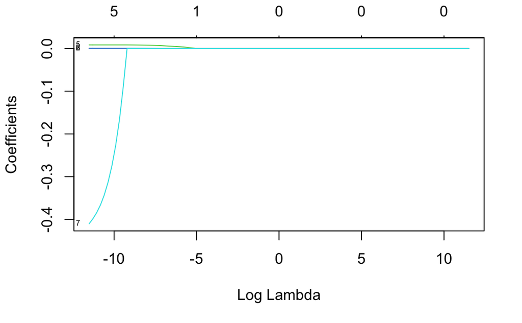

```r
# split data
x.train <- model.matrix(SPY~., one.NYF)
y.train <- one.NYF$SPY

#define mse function
my.mse <- function(pred,act){
  mse <- mean((pred-act)^2)
  return(mse)
}

MSE <- c(NA)
set.seed(1234)
grid <- 10^seq(5,-5,by = -.1)

# model
lasso.fit <- glmnet(x.train,y.train,alpha=1,lambda=grid)
plot(lasso.fit, xvar = "lambda", label = TRUE)
```

```r
# Compute the MSE of each model

for(i in 1:length(grid)){
  lasso.pred.tmp <- predict(lasso.fit,s=grid[i],newx <- x.train)
  MSE[i] <- my.mse(lasso.pred.tmp,y.train)
}
min(MSE)
```

```
[1] 0.001752914
```

```r
#select best lambda
lambda.star <- grid[which.min(MSE)]
lambda.star
```

```
[1] 1e-05
```

```r
# predicting for same data
y_predicted <- predict(lasso.fit, s = lambda.star, newx = x.train)

# calculate R square
sst <- sum((y.train - mean(y_predicted))^2)
ssr <- sum((y_predicted-y.train)^2)
rsq <- 1 - ssr / sst
rsq
```

```
[1] 0.117583
```

```r
# print coefficients of each variables
coef_lasso<-coef(lasso.fit,s=lambda.star)
coef_lasso
```

```
8 x 1 sparse Matrix of class "dgCMatrix"
                            1
(Intercept)     -2.366371e-02
(Intercept)      .
Confirmed        5.651586e-07
Deaths          -4.644676e-06
Recovered        .
Confirmed.chg.1  8.109713e-03
Confirmed.chg.2  2.415890e-04
death.rate      -4.101643e-01
```

Because this dataset is very small, it is hard to perfectly converge. We can see that the R square (0.117) is a small number. But we can get the coefficients of the variables, from which we can have idea about the variables. For exmaple, we can see that the coefficient of `death.rate` is relative larger than others’, which indicates that it might be an important variable that negatively affect the market.

#### 🌟Decision Tree Regression model

```r
library(rpart)
library(rpart.plot)
```

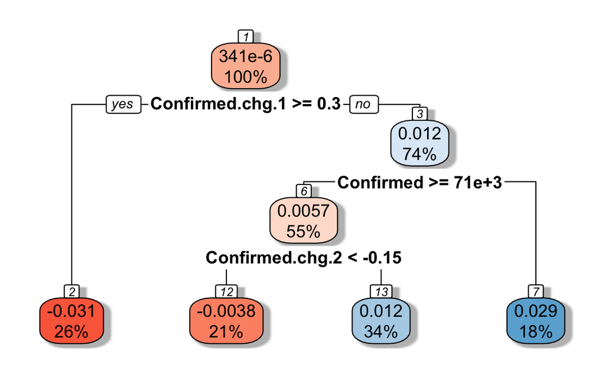

```r
# Create a decision tree model
tree <- rpart(SPY~., data=one.NYF, cp=.001)
# Visualize the decision tree with rpart.plot
rpart.plot(tree, box.palette="RdBu", shadow.col="gray", nn=TRUE)
```

```r
# predict
tree.pred = predict(tree, one.NYF[, -c(1)])
#mean square error
tree.mse=my.mse(tree.pred,y.train)
tree.mse
```

```
[1] 0.001527223
```

Because this dataset only contains 38 records, so that I didn’t conduct the pruning step. The mean squared error of the decision tree regressor `[1]` is less than Lasso regression model. The factors ‘number of confirmed cases’, ‘increase rate’and ’change over change rate’ show critical role at splitting node. I believe the accuracy will be higher when there are more data to be trained in this model.

### The Last

Our existing algorithm is good at finding and applying a relatively fixed, "hard-coded" pattern. Financial market time series is a partial information game (POMDP) process. Various factors drive asset prices at different scales, which is extremely challenging even for humans. It is difficult to expect machines and algorithms to suddenly appear in this field that beyond human ability.

Xia (Charlene) Fu - 15 July 2020